# Section 1: The basics of R

### Indexing in data frames

Indexing in data frames works the same way as for matrices with `data.frame[row, column]`. Alternatively, you can access the columns with a `$` sign and the column name without the quotes.

```r
df.lakes[,"Summer"] # same as matrix
```

```
## [1] "A"    "11.1" "6.8"  "21.6" "12.7" "15.3" "16.8"
```

```r
df.lakes$Summer # data frame specific indexing
```

```
## [1] "A"    "11.1" "6.8"  "21.6" "12.7" "15.3" "16.8"
```

Again, R is always case sensitive. If you are clumsy with capital letters, I advise you to keep everything in small letters and only change for example treatment names in plots, when you are preparing final versions of plots.

To demonstrate the properties of data frames, let’s have a look at one of the built-in data sets in R. Do you remember that the help files of functions always have to contain a working example? Most of these examples use one of the built-in data sets. One of them is `iris`. This data gives flower dimensions for 150 individuals from three iris species.

```r
iris
```

```
##     Sepal.Length Sepal.Width Petal.Length Petal.Width    Species
## 1            5.1         3.5          1.4         0.2     setosa
## 2            4.9         3.0          1.4         0.2     setosa
## 3            4.7         3.2          1.3         0.2     setosa
## 4            4.6         3.1          1.5         0.2     setosa
## 5            5.0         3.6          1.4         0.2     setosa
## 6            5.4         3.9          1.7         0.4     setosa
## 7            4.6         3.4          1.4         0.3     setosa
## 8            5.0         3.4          1.5         0.2     setosa
## 9            4.4         2.9          1.4         0.2     setosa
## 10           4.9         3.1          1.5         0.1     setosa
## 11           5.4         3.7          1.5         0.2     setosa
## 12           4.8         3.4          1.6         0.2     setosa
## 13           4.8         3.0          1.4         0.1     setosa
## 14           4.3         3.0          1.1         0.1     setosa
```

[output cut: 136 more lines]

```r
str(iris) # examine data frame
```

```
## 'data.frame':    150 obs. of  5 variables:
##  $ Sepal.Length: num  5.1 4.9 4.7 4.6 5 5.4 4.6 5 4.4 4.9 ...
##  $ Sepal.Width : num  3.5 3 3.2 3.1 3.6 3.9 3.4 3.4 2.9 3.1 ...
##  $ Petal.Length: num  1.4 1.4 1.3 1.5 1.4 1.7 1.4 1.5 1.4 1.5 ...
##  $ Petal.Width : num  0.2 0.2 0.2 0.2 0.2 0.4 0.3 0.2 0.2 0.1 ...
##  $ Species     : Factor w/ 3 levels "setosa","versicolor",..: 1 1 1 1 1 1 1 1 1 1 ...
```

As before, the *structure* function tells you the most important things about your object. We know that it is a data frame containing 150 rows (‘obs.’) and 5 columns (‘variables’).

Secondly, we can see that four of the five columns are numeric and contain data on the length and width of different flower parts (sepals, petals).

The last column, however, has been classed as a *factor*. Remember? This is the last class type that I had avoided to explain. Factors are a hybrid of character and numeric classes. They appear like characters but are processed like numbers. This is very important, because it means that they can be included in statistics and functions that separate data sets by levels of a factor.

```r
iris[,"Species"] # appears as a character
```

```
##   [1] setosa     setosa     setosa     setosa     setosa     setosa
##   [7] setosa     setosa     setosa     setosa     setosa     setosa
##  [13] setosa     setosa     setosa     setosa     setosa     setosa
##  [19] setosa     setosa     setosa     setosa     setosa     setosa
##  [25] setosa     setosa     setosa     setosa     setosa     setosa
##  [31] setosa     setosa     setosa     setosa     setosa     setosa
##  [37] setosa     setosa     setosa     setosa     setosa     setosa
##  [43] setosa     setosa     setosa     setosa     setosa     setosa
##  [49] setosa     setosa     versicolor versicolor versicolor versicolor
##  [55] versicolor versicolor versicolor versicolor versicolor versicolor
##  [61] versicolor versicolor versicolor versicolor versicolor versicolor
##  [67] versicolor versicolor versicolor versicolor versicolor versicolor
##  [73] versicolor versicolor versicolor versicolor versicolor versicolor
##  [79] versicolor versicolor versicolor versicolor versicolor versicolor
##  [85] versicolor versicolor versicolor versicolor versicolor versicolor
##  [91] versicolor versicolor versicolor versicolor versicolor versicolor
##  [97] versicolor versicolor versicolor versicolor virginica  virginica
## [103] virginica  virginica  virginica  virginica  virginica  virginica
## [109] virginica  virginica  virginica  virginica  virginica  virginica
## [115] virginica  virginica  virginica  virginica  virginica  virginica
## [121] virginica  virginica  virginica  virginica  virginica  virginica
## [127] virginica  virginica  virginica  virginica  virginica  virginica
## [133] virginica  virginica  virginica  virginica  virginica  virginica
## [139] virginica  virginica  virginica  virginica  virginica  virginica
## [145] virginica  virginica  virginica  virginica  virginica  virginica
## Levels: setosa versicolor virginica
```

```r
as.numeric(iris[,"Species"]) # easily converts into a number
```

```
##   [1] 1 1 1 1 1 1 1 1 1 1 1 1 1 1 1 1 1 1 1 1 1 1 1 1 1 1 1 1 1 1 1 1 1 1 1
##  [36] 1 1 1 1 1 1 1 1 1 1 1 1 1 1 1 2 2 2 2 2 2 2 2 2 2 2 2 2 2 2 2 2 2 2 2
##  [71] 2 2 2 2 2 2 2 2 2 2 2 2 2 2 2 2 2 2 2 2 2 2 2 2 2 2 2 2 2 2 3 3 3 3 3
## [106] 3 3 3 3 3 3 3 3 3 3 3 3 3 3 3 3 3 3 3 3 3 3 3 3 3 3 3 3 3 3 3 3 3 3 3
## [141] 3 3 3 3 3 3 3 3 3 3
```

```r
# To see the levels of a factor
levels(iris[,"Species"])
```

```
## [1] "setosa"     "versicolor" "virginica"
```

Now, printing the whole data frame in the console often results in a LOT being printed. Especially if your data frame contains thousands of rows. To avoid loosing the overview of the previous console outputs (without endlessly scrolling), there are the `head()` and `tail()` functions that print only the first and last six rows, respectively.

```r
head(iris)
```

```
##   Sepal.Length Sepal.Width Petal.Length Petal.Width Species
## 1          5.1         3.5          1.4         0.2  setosa
## 2          4.9         3.0          1.4         0.2  setosa
## 3          4.7         3.2          1.3         0.2  setosa
## 4          4.6         3.1          1.5         0.2  setosa
## 5          5.0         3.6          1.4         0.2  setosa
## 6          5.4         3.9          1.7         0.4  setosa
```

```r
tail(iris)
```

```
##     Sepal.Length Sepal.Width Petal.Length Petal.Width   Species
## 145          6.7         3.3          5.7         2.5 virginica
## 146          6.7         3.0          5.2         2.3 virginica
## 147          6.3         2.5          5.0         1.9 virginica
## 148          6.5         3.0          5.2         2.0 virginica
## 149          6.2         3.4          5.4         2.3 virginica
## 150          5.9         3.0          5.1         1.8 virginica
```

### Adding rows and columns

Data frames can be modified by making use of the indexing process, similarly to matrices and vectors. This is particularly useful to create new variables for use in alter analysis without having to delete the original data.

For example, we might want to create a new ‘size’ variable in the iris data set that categorised flowers by sepal length (e.g. small < 5.5, large > 6.5, medium in between).

```r
# creating indices to select rows of different sizes
small <- iris[,"Sepal.Length"] < 5.5
med <- iris[,"Sepal.Length"] >= 5.5 & iris[,"Sepal.Length"] <= 6.5
large <- iris[,"Sepal.Length"] > 6.5
# putting the relevant category in the row of a new 'size' column
# First, add "Small"
iris[small,"Size"] <- "Small"
# see the process of filling the column "Size" sequentially
head(iris)
```

```
##   Sepal.Length Sepal.Width Petal.Length Petal.Width Species  Size
## 1          5.1         3.5          1.4         0.2  setosa Small
## 2          4.9         3.0          1.4         0.2  setosa Small
## 3          4.7         3.2          1.3         0.2  setosa Small
## 4          4.6         3.1          1.5         0.2  setosa Small
## 5          5.0         3.6          1.4         0.2  setosa Small
## 6          5.4         3.9          1.7         0.4  setosa Small
```

```r
tail(iris)
```

```
##     Sepal.Length Sepal.Width Petal.Length Petal.Width   Species Size
## 145          6.7         3.3          5.7         2.5 virginica <NA>
## 146          6.7         3.0          5.2         2.3 virginica <NA>
## 147          6.3         2.5          5.0         1.9 virginica <NA>
## 148          6.5         3.0          5.2         2.0 virginica <NA>
## 149          6.2         3.4          5.4         2.3 virginica <NA>
## 150          5.9         3.0          5.1         1.8 virginica <NA>
```

```r
# Then "Medium"
iris[med,"Size"] <- "Medium"
head(iris)
```

```
##   Sepal.Length Sepal.Width Petal.Length Petal.Width Species  Size
## 1          5.1         3.5          1.4         0.2  setosa Small
## 2          4.9         3.0          1.4         0.2  setosa Small
## 3          4.7         3.2          1.3         0.2  setosa Small
## 4          4.6         3.1          1.5         0.2  setosa Small
## 5          5.0         3.6          1.4         0.2  setosa Small
## 6          5.4         3.9          1.7         0.4  setosa Small
```

```r
tail(iris)
```

```
##     Sepal.Length Sepal.Width Petal.Length Petal.Width   Species   Size
## 145          6.7         3.3          5.7         2.5 virginica   <NA>
## 146          6.7         3.0          5.2         2.3 virginica   <NA>
## 147          6.3         2.5          5.0         1.9 virginica Medium
## 148          6.5         3.0          5.2         2.0 virginica Medium
## 149          6.2         3.4          5.4         2.3 virginica Medium
## 150          5.9         3.0          5.1         1.8 virginica Medium
```

```r
# Finally, "Large"
iris[large,"Size"] <- "Large"
head(iris)
```

```
##   Sepal.Length Sepal.Width Petal.Length Petal.Width Species  Size
## 1          5.1         3.5          1.4         0.2  setosa Small
## 2          4.9         3.0          1.4         0.2  setosa Small
## 3          4.7         3.2          1.3         0.2  setosa Small
## 4          4.6         3.1          1.5         0.2  setosa Small
## 5          5.0         3.6          1.4         0.2  setosa Small
## 6          5.4         3.9          1.7         0.4  setosa Small
```

```r
tail(iris)
```

```
##     Sepal.Length Sepal.Width Petal.Length Petal.Width   Species   Size
## 145          6.7         3.3          5.7         2.5 virginica  Large
## 146          6.7         3.0          5.2         2.3 virginica  Large
## 147          6.3         2.5          5.0         1.9 virginica Medium
## 148          6.5         3.0          5.2         2.0 virginica Medium
## 149          6.2         3.4          5.4         2.3 virginica Medium
## 150          5.9         3.0          5.1         1.8 virginica Medium
```

As a result, we have created a new column with the name ‘Size’ and added three categories (Small, Medium, Large) defined by the size of the sepal length. You could follow the sequential filling of the new column that only fills the columns where the sepal lengths meet the criteria that we had defined. If we would have put the categories in the column “Sepal.Length”, we would have overwritten the existing values, which might become problematic in downstream processes. A good practice is always to keep original data and just add them as a column.

Note that we were able to create a new column named ‘Size’, just by adding it into the `[ ]` and assigning something to it. The alternative is to put the `$` sign and a new column name. However, you always need to assign something in order to create a column. If you want a empty column for whatever reason, either assign a space or NA. You will see that the principle of recycling will be applied if we only assign one element to a whole column.

```r
iris[,"Empty"] <- " " # creating a new column with []
iris$Empty2 <- NA # creating a new column with $
head(iris)
```

```
##   Sepal.Length Sepal.Width Petal.Length Petal.Width Species  Size Empty
## 1          5.1         3.5          1.4         0.2  setosa Small
## 2          4.9         3.0          1.4         0.2  setosa Small
## 3          4.7         3.2          1.3         0.2  setosa Small
## 4          4.6         3.1          1.5         0.2  setosa Small
## 5          5.0         3.6          1.4         0.2  setosa Small
## 6          5.4         3.9          1.7         0.4  setosa Small
##   Empty2
## 1     NA
## 2     NA
## 3     NA
## 4     NA
## 5     NA
## 6     NA
```

One can erase a column by:

```r
iris[,"Empty"] <- NULL
head(iris)
```

```
##   Sepal.Length Sepal.Width Petal.Length Petal.Width Species  Size Empty2
## 1          5.1         3.5          1.4         0.2  setosa Small     NA
## 2          4.9         3.0          1.4         0.2  setosa Small     NA
## 3          4.7         3.2          1.3         0.2  setosa Small     NA
## 4          4.6         3.1          1.5         0.2  setosa Small     NA
## 5          5.0         3.6          1.4         0.2  setosa Small     NA
## 6          5.4         3.9          1.7         0.4  setosa Small     NA
```

```r
iris <- iris[,-7] # re-assigning iris by removing a column
head(iris)
```

```
##   Sepal.Length Sepal.Width Petal.Length Petal.Width Species  Size
## 1          5.1         3.5          1.4         0.2  setosa Small
## 2          4.9         3.0          1.4         0.2  setosa Small
## 3          4.7         3.2          1.3         0.2  setosa Small
## 4          4.6         3.1          1.5         0.2  setosa Small
## 5          5.0         3.6          1.4         0.2  setosa Small
## 6          5.4         3.9          1.7         0.4  setosa Small
```

Finally, it is possible to use indexing to reorder a data frame (or any other object), so it is for example easier to look at the data frame. In the `iris` data set, it might be more logical to have the categorical variables first, followed by the numeric variables. This is done by our universally important `c()` function.

```r
reordered.iris <- iris[,c(5,6,1:4)]
head(reordered.iris)
```

```
##   Species  Size Sepal.Length Sepal.Width Petal.Length Petal.Width
## 1  setosa Small          5.1         3.5          1.4         0.2
## 2  setosa Small          4.9         3.0          1.4         0.2
## 3  setosa Small          4.7         3.2          1.3         0.2
## 4  setosa Small          4.6         3.1          1.5         0.2
## 5  setosa Small          5.0         3.6          1.4         0.2
## 6  setosa Small          5.4         3.9          1.7         0.4
```

Changing column names is also easily done in data frames. We use the same functions as for matrices which are `colnames()` and `rownames()`.

```r
colnames(iris)
```

```
## [1] "Sepal.Length" "Sepal.Width"  "Petal.Length" "Petal.Width"
## [5] "Species"      "Size"
```

```r
rownames(iris) # by default, rownames are the row numbers of a data frame
```

```
##   [1] "1"   "2"   "3"   "4"   "5"   "6"   "7"   "8"   "9"   "10"  "11"
##  [12] "12"  "13"  "14"  "15"  "16"  "17"  "18"  "19"  "20"  "21"  "22"
##  [23] "23"  "24"  "25"  "26"  "27"  "28"  "29"  "30"  "31"  "32"  "33"
##  [34] "34"  "35"  "36"  "37"  "38"  "39"  "40"  "41"  "42"  "43"  "44"
##  [45] "45"  "46"  "47"  "48"  "49"  "50"  "51"  "52"  "53"  "54"  "55"
##  [56] "56"  "57"  "58"  "59"  "60"  "61"  "62"  "63"  "64"  "65"  "66"
##  [67] "67"  "68"  "69"  "70"  "71"  "72"  "73"  "74"  "75"  "76"  "77"
##  [78] "78"  "79"  "80"  "81"  "82"  "83"  "84"  "85"  "86"  "87"  "88"
##  [89] "89"  "90"  "91"  "92"  "93"  "94"  "95"  "96"  "97"  "98"  "99"
## [100] "100" "101" "102" "103" "104" "105" "106" "107" "108" "109" "110"
## [111] "111" "112" "113" "114" "115" "116" "117" "118" "119" "120" "121"
## [122] "122" "123" "124" "125" "126" "127" "128" "129" "130" "131" "132"
## [133] "133" "134" "135" "136" "137" "138" "139" "140" "141" "142" "143"
## [144] "144" "145" "146" "147" "148" "149" "150"
```

You can either specify single column/row names or multiple.

```r
colnames(iris)[1] <- "sepal.length" # removing capitals, because I don't like them
head(iris)
```

```
##   sepal.length Sepal.Width Petal.Length Petal.Width Species  Size
## 1          5.1         3.5          1.4         0.2  setosa Small
## 2          4.9         3.0          1.4         0.2  setosa Small
## 3          4.7         3.2          1.3         0.2  setosa Small
## 4          4.6         3.1          1.5         0.2  setosa Small
## 5          5.0         3.6          1.4         0.2  setosa Small
## 6          5.4         3.9          1.7         0.4  setosa Small
```

```r
colnames(iris)[3:4] <- c("petal.length", "petal.width") # do not forget the c() for multiple elements
head(iris)
```

```
##   sepal.length Sepal.Width petal.length petal.width Species  Size
## 1          5.1         3.5          1.4         0.2  setosa Small
## 2          4.9         3.0          1.4         0.2  setosa Small
## 3          4.7         3.2          1.3         0.2  setosa Small
## 4          4.6         3.1          1.5         0.2  setosa Small
## 5          5.0         3.6          1.4         0.2  setosa Small
## 6          5.4         3.9          1.7         0.4  setosa Small
```

```r
colnames(iris)[c(2,5)] <- c("sepal.width", "species")
head(iris)
```

```
##   sepal.length sepal.width petal.length petal.width species  Size
## 1          5.1         3.5          1.4         0.2  setosa Small
## 2          4.9         3.0          1.4         0.2  setosa Small
## 3          4.7         3.2          1.3         0.2  setosa Small
## 4          4.6         3.1          1.5         0.2  setosa Small
## 5          5.0         3.6          1.4         0.2  setosa Small
## 6          5.4         3.9          1.7         0.4  setosa Small
```

```r
# same works for row names
rownames(iris)[1] <- "first row"
rownames(iris)
```

```
##   [1] "first row" "2"         "3"         "4"         "5"
##   [6] "6"         "7"         "8"         "9"         "10"
##  [11] "11"        "12"        "13"        "14"        "15"
##  [16] "16"        "17"        "18"        "19"        "20"
##  [21] "21"        "22"        "23"        "24"        "25"
##  [26] "26"        "27"        "28"        "29"        "30"
##  [31] "31"        "32"        "33"        "34"        "35"
##  [36] "36"        "37"        "38"        "39"        "40"
##  [41] "41"        "42"        "43"        "44"        "45"
##  [46] "46"        "47"        "48"        "49"        "50"
##  [51] "51"        "52"        "53"        "54"        "55"
##  [56] "56"        "57"        "58"        "59"        "60"
##  [61] "61"        "62"        "63"        "64"        "65"
##  [66] "66"        "67"        "68"        "69"        "70"
##  [71] "71"        "72"        "73"        "74"        "75"
##  [76] "76"        "77"        "78"        "79"        "80"
##  [81] "81"        "82"        "83"        "84"        "85"
##  [86] "86"        "87"        "88"        "89"        "90"
##  [91] "91"        "92"        "93"        "94"        "95"
##  [96] "96"        "97"        "98"        "99"        "100"
## [101] "101"       "102"       "103"       "104"       "105"
## [106] "106"       "107"       "108"       "109"       "110"
## [111] "111"       "112"       "113"       "114"       "115"
## [116] "116"       "117"       "118"       "119"       "120"
## [121] "121"       "122"       "123"       "124"       "125"
## [126] "126"       "127"       "128"       "129"       "130"
## [131] "131"       "132"       "133"       "134"       "135"
## [136] "136"       "137"       "138"       "139"       "140"
## [141] "141"       "142"       "143"       "144"       "145"
## [146] "146"       "147"       "148"       "149"       "150"
```

## Lists

While it is less common to create *lists* by yourself for your data analysis, many functions create lists as outputs. Therefore, it is crucial to understand how to read and extract information from them.

*Lists* are basically objects that can store other objects inside them. Therefore, *lists* are nested objects that are multi-dimensional. I usually imagine it to be a vector of baskets (called **bins**). In each basket you can store a single R object such as vectors, matrices, data frames, even models and other lists (!). Those objects can be completely unrelated to each other.

Sounds complex? It is. Let’s create one with the `list()` function and objects we have used before:

```r
c.vector # our hello vector
```

```
## [1] "hello"   "R"       ","       "you"     "are"     "awesome"
```

```r
b # a numeric matrix
```

```
##      [,1] [,2]
## [1,]    1    6
## [2,]    2    7
## [3,]    3    8
## [4,]    4    9
## [5,]    5   10
```

```r
(mini.iris <- iris[1:5,]) # a small extraction of our iris data set
```

```
##           sepal.length sepal.width petal.length petal.width species  Size
## first row          5.1         3.5          1.4         0.2  setosa Small
## 2                  4.9         3.0          1.4         0.2  setosa Small
## 3                  4.7         3.2          1.3         0.2  setosa Small
## 4                  4.6         3.1          1.5         0.2  setosa Small
## 5                  5.0         3.6          1.4         0.2  setosa Small
```

```r
my.list <- list(c.vector, b, mini.iris)
my.list
```

```
## [[1]]
## [1] "hello"   "R"       ","       "you"     "are"     "awesome"
##
## [[2]]
##      [,1] [,2]
## [1,]    1    6
## [2,]    2    7
## [3,]    3    8
## [4,]    4    9
## [5,]    5   10
##
## [[3]]
##           sepal.length sepal.width petal.length petal.width species  Size
## first row          5.1         3.5          1.4         0.2  setosa Small
## 2                  4.9         3.0          1.4         0.2  setosa Small
## 3                  4.7         3.2          1.3         0.2  setosa Small
## 4                  4.6         3.1          1.5         0.2  setosa Small
## 5                  5.0         3.6          1.4         0.2  setosa Small
```

Looking at a list might appear confusing at first. But you’ll see that there is a structure that is indeed familiar. Printing `my.list`, gives us all three objects. Each object is printed directly underneath the double square brackets `[[ ]]`, which are the **bin** numbers. **Bin** numbers indicate the position of each object inside the list. So `c.vector` is in bin number 1, `b` matrix in bin number 2, and `mini.iris` in bin 3. It’s exactly the same sequence as we have fed them to the function `list()`. And the rest of the object is already familiar to us. We can see the `[1]` for the vector, the `[1,]` and `[,1]` for rows and columns of the matrix, and the column names and row names of our data frame. So, we have created an object that is a *list*, containing several objects in **bins** that are not connected in any way.

```r
str(my.list)
```

```
## List of 3
##  $ : chr [1:6] "hello" "R" "," "you" ...
##  $ : int [1:5, 1:2] 1 2 3 4 5 6 7 8 9 10
##  $ :'data.frame':    5 obs. of  6 variables:
##   ..$ sepal.length: num [1:5] 5.1 4.9 4.7 4.6 5
##   ..$ sepal.width : num [1:5] 3.5 3 3.2 3.1 3.6
##   ..$ petal.length: num [1:5] 1.4 1.4 1.3 1.5 1.4
##   ..$ petal.width : num [1:5] 0.2 0.2 0.2 0.2 0.2
##   ..$ species     : Factor w/ 3 levels "setosa","versicolor",..: 1 1 1 1 1
##   ..$ Size        : chr [1:5] "Small" "Small" "Small" "Small" ...
```

Our favourite function `str()` shows us essentially the same but in a much more compact and (I think) easier to read manner. So, we can see that we have a *list* with 3 bins. These are indicated by the three `$` signs on the left. It tells us what type of object is in each bin (e.g. vector, matrix, data frame) and what the dimensions are (number of rows and columns). The only a bit more complex thing is the second row of `$` signs inside the bin that contains a data frame. But this is simple the same information that we get if we run the `str()` function on a data frame.

```r
str(mini.iris)
```

```
## 'data.frame':    5 obs. of  6 variables:
##  $ sepal.length: num  5.1 4.9 4.7 4.6 5
##  $ sepal.width : num  3.5 3 3.2 3.1 3.6
##  $ petal.length: num  1.4 1.4 1.3 1.5 1.4
##  $ petal.width : num  0.2 0.2 0.2 0.2 0.2
##  $ species     : Factor w/ 3 levels "setosa","versicolor",..: 1 1 1 1 1
##  $ Size        : chr  "Small" "Small" "Small" "Small" ...
```

In summary, when we inspect a list, we get information about the structure of the list itself *and* the structure of the objects stored within.

### Indexing in lists

Bins can also be named with the `names()` function after the list has been created. Or by naming them when creating a new list.

```r
# naming bins of an existing list
names(my.list) <- c("Vector","Matrix","Data.frame")
my.list
```

```
## $Vector
## [1] "hello"   "R"       ","       "you"     "are"     "awesome"
##
## $Matrix
##      [,1] [,2]
## [1,]    1    6
## [2,]    2    7
## [3,]    3    8
## [4,]    4    9
## [5,]    5   10
##
## $Data.frame
##           sepal.length sepal.width petal.length petal.width species  Size
## first row          5.1         3.5          1.4         0.2  setosa Small
## 2                  4.9         3.0          1.4         0.2  setosa Small
## 3                  4.7         3.2          1.3         0.2  setosa Small
## 4                  4.6         3.1          1.5         0.2  setosa Small
## 5                  5.0         3.6          1.4         0.2  setosa Small
```

```r
# creating a new list with names specified as arguments
new.list <- list(Vector = c.vector, Matrix = b, Data.frame = mini.iris)
new.list
```

```
## $Vector
## [1] "hello"   "R"       ","       "you"     "are"     "awesome"
##
## $Matrix
##      [,1] [,2]
## [1,]    1    6
## [2,]    2    7
## [3,]    3    8
## [4,]    4    9
## [5,]    5   10
##
## $Data.frame
##           sepal.length sepal.width petal.length petal.width species  Size
## first row          5.1         3.5          1.4         0.2  setosa Small
## 2                  4.9         3.0          1.4         0.2  setosa Small
## 3                  4.7         3.2          1.3         0.2  setosa Small
## 4                  4.6         3.1          1.5         0.2  setosa Small
## 5                  5.0         3.6          1.4         0.2  setosa Small
```

However, you will see that naming the bins, gets rid of the `[[ ]]` and consequently the number of the bin position. Which could be counter productive in certain circumstances.

**TIP**: creating a new data frame works the same way as for lists by specifying the column names as arguments inside the `data.frame()` function. Example: `df <- data.frame(First.vector = v1, Second.vector = v2)`.

To name elements inside the objects within the bins, we have to know how to isolate and access each bin separately. Most commonly this is done by **position**:

```r
# using double square brackets to extract the bins
my.list[[1]] # 1st bin, which is the vector
```

```
## [1] "hello"   "R"       ","       "you"     "are"     "awesome"
```

```r
my.list[[2]] # 2nd bin, which is the matrix
```

```
##      [,1] [,2]
## [1,]    1    6
## [2,]    2    7
## [3,]    3    8
## [4,]    4    9
## [5,]    5   10
```

```r
my.list[[3]] # 3rd bin, which is the data frame
```

```
##           sepal.length sepal.width petal.length petal.width species  Size
## first row          5.1         3.5          1.4         0.2  setosa Small
## 2                  4.9         3.0          1.4         0.2  setosa Small
## 3                  4.7         3.2          1.3         0.2  setosa Small
## 4                  4.6         3.1          1.5         0.2  setosa Small
## 5                  5.0         3.6          1.4         0.2  setosa Small
```

Secondly, we can do this by **name**:

```r
my.list[["Vector"]]
```

```
## [1] "hello"   "R"       ","       "you"     "are"     "awesome"
```

```r
my.list$Vector
```

```
## [1] "hello"   "R"       ","       "you"     "are"     "awesome"
```

In the above examples, the bin name was not printed alongside the content of the object. It is possible to include it by indexing with a single set of square brackets, which returns the name of the bin in addition to its contents:

```r
my.list[1] # bin 1, by position
```

```
## $Vector
## [1] "hello"   "R"       ","       "you"     "are"     "awesome"
```

```r
my.list["Vector"] # bin 1, by name
```

```
## $Vector
## [1] "hello"   "R"       ","       "you"     "are"     "awesome"
```

When isolating bins from a lists, one has to consider whether the name of the bin should be included in the output. While is useful to know which bin is being selected, many functions cannot deal with this extra information.

Therefore, it is often more useful to only print the content of the object and excluding bin names by indexing with the `[[ ]]`. This way, an object inside a list can be treated the same way as a alone-standing object. With this in mind, any other operation can be done quite easily:

```r
my.list$Matrix # printing the content of the numeric matrix
```

```
##      [,1] [,2]
## [1,]    1    6
## [2,]    2    7
## [3,]    3    8
## [4,]    4    9
## [5,]    5   10
```

```r
rownames(my.list$Matrix) <- c("A","B","C","D","E") # using $
colnames(my.list[["Matrix"]]) <- c("x","y") # using square brackets
my.list # printing the entire list
```

```
## $Vector
## [1] "hello"   "R"       ","       "you"     "are"     "awesome"
##
## $Matrix
##   x  y
## A 1  6
## B 2  7
## C 3  8
## D 4  9
## E 5 10
##
## $Data.frame
##           sepal.length sepal.width petal.length petal.width species  Size
## first row          5.1         3.5          1.4         0.2  setosa Small
## 2                  4.9         3.0          1.4         0.2  setosa Small
## 3                  4.7         3.2          1.3         0.2  setosa Small
## 4                  4.6         3.1          1.5         0.2  setosa Small
## 5                  5.0         3.6          1.4         0.2  setosa Small
```

Notice that also for lists you can index with brackets or the `$` sign. Use whatever you prefer.

Now, that we know how the select individual bins from lists, indexing the objects within works the same way as if they were ‘normal’ objects.

```r
# extract a column of the data frame
my.list$Data.frame[,"sepal.length"]
```

```
## [1] 5.1 4.9 4.7 4.6 5.0
```

```r
# fourth element of our vector
my.list$Vector[4]
```

```
## [1] "you"
```

```r
# remove values less than 9 and bigger than 6 in y column of matrix
values.index <- my.list$Matrix[,"y"] > 6 & my.list$Matrix[,"y"] < 9 # locate

my.list$Matrix[values.index, "y"] <- NA # change those fulfilling conditions with NA
my.list
```

```
## $Vector
## [1] "hello"   "R"       ","       "you"     "are"     "awesome"
##
## $Matrix
##   x  y
## A 1  6
## B 2 NA
## C 3 NA
## D 4  9
## E 5 10
##
## $Data.frame
##           sepal.length sepal.width petal.length petal.width species  Size
## first row          5.1         3.5          1.4         0.2  setosa Small
## 2                  4.9         3.0          1.4         0.2  setosa Small
## 3                  4.7         3.2          1.3         0.2  setosa Small
## 4                  4.6         3.1          1.5         0.2  setosa Small
## 5                  5.0         3.6          1.4         0.2  setosa Small
```

#### Linear models

So why bother about lists? As said before, many outputs in R are stored in lists, including linear models. Let’s create a simple ANOVA testing whether sepal length significantly differs between species.

```r
str(iris)
```

```
## 'data.frame':    150 obs. of  6 variables:
##  $ sepal.length: num  5.1 4.9 4.7 4.6 5 5.4 4.6 5 4.4 4.9 ...
##  $ sepal.width : num  3.5 3 3.2 3.1 3.6 3.9 3.4 3.4 2.9 3.1 ...
##  $ petal.length: num  1.4 1.4 1.3 1.5 1.4 1.7 1.4 1.5 1.4 1.5 ...
##  $ petal.width : num  0.2 0.2 0.2 0.2 0.2 0.4 0.3 0.2 0.2 0.1 ...
##  $ species     : Factor w/ 3 levels "setosa","versicolor",..: 1 1 1 1 1 1 1 1 1 1 ...
##  $ Size        : chr  "Small" "Small" "Small" "Small" ...
```

So the variables we are interested in are “sepal.length” - a numeric variable -, which is appropriate for a dependent variable, and “species” - a categorical variable - in this case a factor but also OK for an ANOVA.

A linear model is created by the function `lm()` and has to be assigned to an object so we can access the output later on.

```r
anova <- lm(sepal.length ~ species, data = iris)
```

The formula specifies that we are interested in whether sepal length is related or dependent on `~` species. And the function knows to perform an ANOVA, because species is a factor. Finally, we have to indicate the `data =` argument, which is the data frame we feed to the function. Because we indicate the data frame in the `data =` argument, the column names inside the formula are not inside quotes as we normally do for column names when indexing.

Let us have a look at the model:

```r
str(anova)
```

```
## List of 13
##  $ coefficients : Named num [1:3] 5.01 0.93 1.58
##   ..- attr(*, "names")= chr [1:3] "(Intercept)" "speciesversicolor" "speciesvirginica"
##  $ residuals    : Named num [1:150] 0.094 -0.106 -0.306 -0.406 -0.006 ...
##   ..- attr(*, "names")= chr [1:150] "first row" "2" "3" "4" ...
##  $ effects      : Named num [1:150] -71.5659 0.8025 7.91 -0.3826 0.0174 ...
##   ..- attr(*, "names")= chr [1:150] "(Intercept)" "speciesversicolor" "speciesvirginica" "" ...
##  $ rank         : int 3
##  $ fitted.values: Named num [1:150] 5.01 5.01 5.01 5.01 5.01 ...
##   ..- attr(*, "names")= chr [1:150] "first row" "2" "3" "4" ...
##  $ assign       : int [1:3] 0 1 1
##  $ qr           :List of 5
##   ..$ qr   : num [1:150, 1:3] -12.2474 0.0816 0.0816 0.0816 0.0816 ...
##   .. ..- attr(*, "dimnames")=List of 2
##   .. .. ..$ : chr [1:150] "first row" "2" "3" "4" ...
##   .. .. ..$ : chr [1:3] "(Intercept)" "speciesversicolor" "speciesvirginica"
##   .. ..- attr(*, "assign")= int [1:3] 0 1 1
##   .. ..- attr(*, "contrasts")=List of 1
##   .. .. ..$ species: chr "contr.treatment"
##   ..$ qraux: num [1:3] 1.08 1.05 1.09
##   ..$ pivot: int [1:3] 1 2 3
##   ..$ tol  : num 1e-07
##   ..$ rank : int 3
##   ..- attr(*, "class")= chr "qr"
##  $ df.residual  : int 147
##  $ contrasts    :List of 1
##   ..$ species: chr "contr.treatment"
##  $ xlevels      :List of 1
##   ..$ species: chr [1:3] "setosa" "versicolor" "virginica"
##  $ call         : language lm(formula = sepal.length ~ species, data = iris)
##  $ terms        :Classes 'terms', 'formula'  language sepal.length ~ species
##   .. ..- attr(*, "variables")= language list(sepal.length, species)
##   .. ..- attr(*, "factors")= int [1:2, 1] 0 1
##   .. .. ..- attr(*, "dimnames")=List of 2
##   .. .. .. ..$ : chr [1:2] "sepal.length" "species"
##   .. .. .. ..$ : chr "species"
##   .. ..- attr(*, "term.labels")= chr "species"
##   .. ..- attr(*, "order")= int 1
##   .. ..- attr(*, "intercept")= int 1
##   .. ..- attr(*, "response")= int 1
##   .. ..- attr(*, ".Environment")=<environment: R_GlobalEnv>
##   .. ..- attr(*, "predvars")= language list(sepal.length, species)
##   .. ..- attr(*, "dataClasses")= Named chr [1:2] "numeric" "factor"
##   .. .. ..- attr(*, "names")= chr [1:2] "sepal.length" "species"
##  $ model        :'data.frame':   150 obs. of  2 variables:
##   ..$ sepal.length: num [1:150] 5.1 4.9 4.7 4.6 5 5.4 4.6 5 4.4 4.9 ...
##   ..$ species     : Factor w/ 3 levels "setosa","versicolor",..: 1 1 1 1 1 1 1 1 1 1 ...
##   ..- attr(*, "terms")=Classes 'terms', 'formula'  language sepal.length ~ species
##   .. .. ..- attr(*, "variables")= language list(sepal.length, species)
##   .. .. ..- attr(*, "factors")= int [1:2, 1] 0 1
##   .. .. .. ..- attr(*, "dimnames")=List of 2
##   .. .. .. .. ..$ : chr [1:2] "sepal.length" "species"
##   .. .. .. .. ..$ : chr "species"
##   .. .. ..- attr(*, "term.labels")= chr "species"
##   .. .. ..- attr(*, "order")= int 1
##   .. .. ..- attr(*, "intercept")= int 1
##   .. .. ..- attr(*, "response")= int 1
##   .. .. ..- attr(*, ".Environment")=<environment: R_GlobalEnv>
##   .. .. ..- attr(*, "predvars")= language list(sepal.length, species)
##   .. .. ..- attr(*, "dataClasses")= Named chr [1:2] "numeric" "factor"
##   .. .. .. ..- attr(*, "names")= chr [1:2] "sepal.length" "species"
##  - attr(*, "class")= chr "lm"
```

You can see that the output is a quite big list with 13 bins. A way of reducing information to only the most necessary is by excluding attributes with the `give.attr = FALSE` argument.

```r
str(anova, give.attr = FALSE) # excluding attributes
```

```
## List of 13
##  $ coefficients : Named num [1:3] 5.01 0.93 1.58
##  $ residuals    : Named num [1:150] 0.094 -0.106 -0.306 -0.406 -0.006 ...
##  $ effects      : Named num [1:150] -71.5659 0.8025 7.91 -0.3826 0.0174 ...
##  $ rank         : int 3
##  $ fitted.values: Named num [1:150] 5.01 5.01 5.01 5.01 5.01 ...
##  $ assign       : int [1:3] 0 1 1
##  $ qr           :List of 5
##   ..$ qr   : num [1:150, 1:3] -12.2474 0.0816 0.0816 0.0816 0.0816 ...
##   ..$ qraux: num [1:3] 1.08 1.05 1.09
##   ..$ pivot: int [1:3] 1 2 3
##   ..$ tol  : num 1e-07
##   ..$ rank : int 3
##  $ df.residual  : int 147
##  $ contrasts    :List of 1
##   ..$ species: chr "contr.treatment"
##  $ xlevels      :List of 1
##   ..$ species: chr [1:3] "setosa" "versicolor" "virginica"
##  $ call         : language lm(formula = sepal.length ~ species, data = iris)
##  $ terms        :Classes 'terms', 'formula'  language sepal.length ~ species
##  $ model        :'data.frame':   150 obs. of  2 variables:
##   ..$ sepal.length: num [1:150] 5.1 4.9 4.7 4.6 5 5.4 4.6 5 4.4 4.9 ...
##   ..$ species     : Factor w/ 3 levels "setosa","versicolor",..: 1 1 1 1 1 1 1 1 1 1 ...
```

There is no need to go through it in detail yet, but we can still read this output the same way as any other list. So you could isolate things of interest.

```r
anova$coefficients # all coefficients for different levels of the factor species
```

```
##       (Intercept) speciesversicolor  speciesvirginica
##             5.006             0.930             1.582
```

```r
anova$coefficients[2] # only coefficent for the species versicolor
```

```
## speciesversicolor
##              0.93
```

```r
anova$residuals # model residuals for assessing the fit of model
```

```
## first row         2         3         4         5         6         7
##     0.094    -0.106    -0.306    -0.406    -0.006     0.394    -0.406
##         8         9        10        11        12        13        14
##    -0.006    -0.606    -0.106     0.394    -0.206    -0.206    -0.706
##        15        16        17        18        19        20        21
##     0.794     0.694     0.394     0.094     0.694     0.094     0.394
##        22        23        24        25        26        27        28
##     0.094    -0.406     0.094    -0.206    -0.006    -0.006     0.194
##        29        30        31        32        33        34        35
##     0.194    -0.306    -0.206     0.394     0.194     0.494    -0.106
##        36        37        38        39        40        41        42
##    -0.006     0.494    -0.106    -0.606     0.094    -0.006    -0.506
##        43        44        45        46        47        48        49
##    -0.606    -0.006     0.094    -0.206     0.094    -0.406     0.294
##        50        51        52        53        54        55        56
##    -0.006     1.064     0.464     0.964    -0.436     0.564    -0.236
##        57        58        59        60        61        62        63
##     0.364    -1.036     0.664    -0.736    -0.936    -0.036     0.064
##        64        65        66        67        68        69        70
##     0.164    -0.336     0.764    -0.336    -0.136     0.264    -0.336
##        71        72        73        74        75        76        77
##    -0.036     0.164     0.364     0.164     0.464     0.664     0.864
##        78        79        80        81        82        83        84
##     0.764     0.064    -0.236    -0.436    -0.436    -0.136     0.064
##        85        86        87        88        89        90        91
##    -0.536     0.064     0.764     0.364    -0.336    -0.436    -0.436
##        92        93        94        95        96        97        98
##     0.164    -0.136    -0.936    -0.336    -0.236    -0.236     0.264
##        99       100       101       102       103       104       105
##    -0.836    -0.236    -0.288    -0.788     0.512    -0.288    -0.088
##       106       107       108       109       110       111       112
##     1.012    -1.688     0.712     0.112     0.612    -0.088    -0.188
##       113       114       115       116       117       118       119
##     0.212    -0.888    -0.788    -0.188    -0.088     1.112     1.112
##       120       121       122       123       124       125       126
##    -0.588     0.312    -0.988     1.112    -0.288     0.112     0.612
##       127       128       129       130       131       132       133
##    -0.388    -0.488    -0.188     0.612     0.812     1.312    -0.188
##       134       135       136       137       138       139       140
##    -0.288    -0.488     1.112    -0.288    -0.188    -0.588     0.312
##       141       142       143       144       145       146       147
##     0.112     0.312    -0.788     0.212     0.112     0.112    -0.288
##       148       149       150
##    -0.088    -0.388    -0.688
```

```r
anova$fitted.values # fitted values of the model
```

```
## first row         2         3         4         5         6         7
##     5.006     5.006     5.006     5.006     5.006     5.006     5.006
##         8         9        10        11        12        13        14
##     5.006     5.006     5.006     5.006     5.006     5.006     5.006
##        15        16        17        18        19        20        21
##     5.006     5.006     5.006     5.006     5.006     5.006     5.006
##        22        23        24        25        26        27        28
##     5.006     5.006     5.006     5.006     5.006     5.006     5.006
##        29        30        31        32        33        34        35
##     5.006     5.006     5.006     5.006     5.006     5.006     5.006
##        36        37        38        39        40        41        42
##     5.006     5.006     5.006     5.006     5.006     5.006     5.006
##        43        44        45        46        47        48        49
##     5.006     5.006     5.006     5.006     5.006     5.006     5.006
##        50        51        52        53        54        55        56
##     5.006     5.936     5.936     5.936     5.936     5.936     5.936
##        57        58        59        60        61        62        63
##     5.936     5.936     5.936     5.936     5.936     5.936     5.936
##        64        65        66        67        68        69        70
##     5.936     5.936     5.936     5.936     5.936     5.936     5.936
##        71        72        73        74        75        76        77
##     5.936     5.936     5.936     5.936     5.936     5.936     5.936
##        78        79        80        81        82        83        84
##     5.936     5.936     5.936     5.936     5.936     5.936     5.936
##        85        86        87        88        89        90        91
##     5.936     5.936     5.936     5.936     5.936     5.936     5.936
##        92        93        94        95        96        97        98
##     5.936     5.936     5.936     5.936     5.936     5.936     5.936
##        99       100       101       102       103       104       105
##     5.936     5.936     6.588     6.588     6.588     6.588     6.588
##       106       107       108       109       110       111       112
##     6.588     6.588     6.588     6.588     6.588     6.588     6.588
##       113       114       115       116       117       118       119
##     6.588     6.588     6.588     6.588     6.588     6.588     6.588
##       120       121       122       123       124       125       126
##     6.588     6.588     6.588     6.588     6.588     6.588     6.588
##       127       128       129       130       131       132       133
##     6.588     6.588     6.588     6.588     6.588     6.588     6.588
##       134       135       136       137       138       139       140
##     6.588     6.588     6.588     6.588     6.588     6.588     6.588
##       141       142       143       144       145       146       147
##     6.588     6.588     6.588     6.588     6.588     6.588     6.588
##       148       149       150
##     6.588     6.588     6.588
```

```r
anova$call # original formula used to define the model
```

```
## lm(formula = sepal.length ~ species, data = iris)
```

**To add a final remark:** Every time we close a R session, all of your R objects will disappear. That’s why it is important to write in and save your script a sequence of executions that coherently work. The goal is to re-create all your R objects that you need the next time you open the R script if you have not finished your analysis. Keep in mind that several days or months can pass between you working R, so always annotate comments with `#`. Even if you’re the author, you’ll be surprised how few you understand after some time has passed.

In case you have finished your analysis, it is wise to save the objects of interests as tables to your local computer, but we will cover this later.

### Challenge #2:

1. Inspect the iris data frame and make a new matrix of the numeric variables in it (try `as.matrix()`)
2. Rename the columns of the matrix with abbreviations of the existing headings
3. The petal width column is currently in cm, but the analysis requires it to be in mm. Correct this.
4. Convert the matrix into a data frame, and add categories to a new column that separates folowers based on peta width:
   - fucking.small - smaller than 8 mm
   - medium - equal to or bigger than 8 mm and smaller thamn 17 mm
   - large - larger than or equal to 17 mm
5. Your supervisor thinks ‘fucking.small’ is inappropriate. Change all occurrences in this category in the size column to ‘small’ instead.
6. Your supervisor also hates big flowers. Find the flowers that have sepal lengths bigger than 6 and replace the values in **ALL** columns with NA.
7. Create a list with following code: `a.list <- list(1:10, iris[1:10,], lm(petal.width ~ species, data = iris), mean)`
   1. What are the classes of the objects contained in the bins?
   2. Rename the bins to reflect these classes.
   3. What is the standard derviation of the Petal Width column in the bin 2 data (use `sd()`)?
   4. Print the coefficients of the linear model contained in bin 3.

*Solutions* are at the bottom of this document.

# Summary

In conclusion, every object in R can be created, manipulated and interpreted using a relatively small set of rules - which apply universally in the R language. Even large and more complex lists such as the outputs of linear models.

Here is a nice graph from a [R workshop](https://github.com/edamame-course/2018-Tutorials/blob/master/Intro_R_RStudio/R_tutorial.md) that I once attended, that sum up the R objects quite nicely:

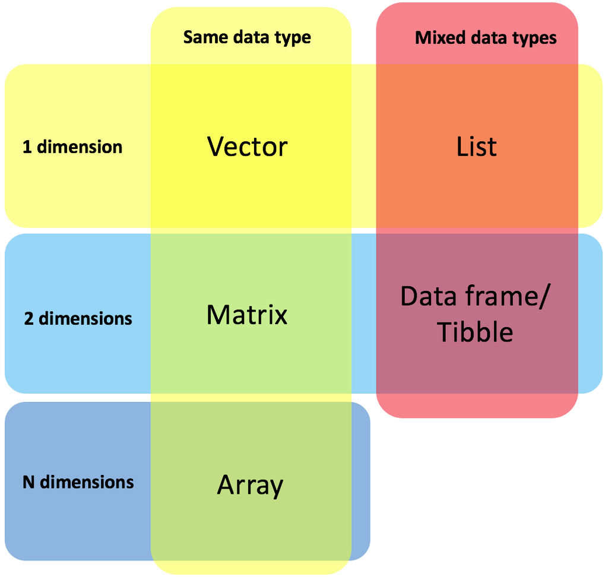

These are the basics of the R language. Most of the common errors and frustrations in R emerge from a lack of understanding of these basics. My first R courses taught me these basics the hard way by digging directly into complex statistics. I’ve grown up gaming in my childhood, so I could enjoy the challenge of R as a new gaming platform. Frankly speaking, I still have the feeling of gaming when I work in R. However, I’ve seen all my colleagues getting discouraged and distancing themselves from R because they’ve never been introduced to the language properly. So, this section might have appeared a bit dry to you, but once you have understood these basics of the language, you will find yourself enjoying the limitless application of R. The learning curve is quite steep at the beginning, it is hard to understand, especially if it is your first time coding. But do not get discouraged! As with anything you learn, **stick with it**. Do the most simplest things in R. Calculate new values from your raw data in R rather than going back to excel. Do not get me wrong, excel is powerful in certain ways. But in my opinion, it is the main cause of human error in research. How bad would it be to realise an error in published data that could be traced back to a single copy and paste mistake in your raw data? I’m pretty sure this happened plenty of times.

In the next section I will introduce you to how to organise your data with R Studio so we’ll get a short break from coding.

# Possible solutions:

## Challenge #1:

1:

```r
spring <- c(23.2, 23.0, 30.1, 39.4, 24.2, 29.1, 31.7)
summer <- c(22.5, 21.1, 26.8, 31.6, 22.7, 25.3, 26.8)
```

2:

```r
lakes <- c("A","B","C","D","E","F","G")
names(spring) <- lakes
names(summer) <- lakes
```

3:

```r
mean(spring); mean(summer)
```

```
## [1] 28.67143
```

```
## [1] 25.25714
```

```r
max(spring); max(summer)
```

```
## [1] 39.4
```

```
## [1] 31.6
```

```r
min(summer); min(summer)
```

```
## [1] 21.1
```

```
## [1] 21.1
```

4:

```r
ascending <- order(spring)
spring[ascending]
```

```
##    B    A    E    F    C    G    D
## 23.0 23.2 24.2 29.1 30.1 31.7 39.4
```

```r
# Or one line code
spring[order(spring)]
```

```
##    B    A    E    F    C    G    D
## 23.0 23.2 24.2 29.1 30.1 31.7 39.4
```

5:

```r
deeper.15 <- spring > 30
spring[deeper.15]
```

```
##    C    D    G
## 30.1 39.4 31.7
```

```r
# more efficiently
spring[spring > 30]
```

```
##    C    D    G
## 30.1 39.4 31.7
```

6:

```r
deeper.15.shallower.10 <- summer > 25 & summer < 30
summer[deeper.15.shallower.10]
```

```
##    C    F    G
## 26.8 25.3 26.8
```

```r
# more efficiently
summer[summer > 25 & summer < 30]
```

```
##    C    F    G
## 26.8 25.3 26.8
```

7:

```r
prop.summer <- spring / summer
prop.change <- prop.summer - 1
(perc.change <- prop.change * 100)
```

```
##         A         B         C         D         E         F         G
##  3.111111  9.004739 12.313433 24.683544  6.607930 15.019763 18.283582
```

```r
# or one line
(perc.change <- ((spring / summer) - 1) * 100)
```

```
##         A         B         C         D         E         F         G
##  3.111111  9.004739 12.313433 24.683544  6.607930 15.019763 18.283582
```

## Challenge #2:

1:

```r
head(iris)
```

```
##           sepal.length sepal.width petal.length petal.width species  Size
## first row          5.1         3.5          1.4         0.2  setosa Small
## 2                  4.9         3.0          1.4         0.2  setosa Small
## 3                  4.7         3.2          1.3         0.2  setosa Small
## 4                  4.6         3.1          1.5         0.2  setosa Small
## 5                  5.0         3.6          1.4         0.2  setosa Small
## 6                  5.4         3.9          1.7         0.4  setosa Small
```

```r
matrix <- as.matrix(iris[,1:4])
```

2:

```r
colnames(matrix) <- c("SL","SW","PL","PW")
```

3:

```r
matrix[,"PW"] <- matrix[,"PW"] * 10
```

4:

```r
df <- as.data.frame(matrix)
fs.index <- df$PW < 8
m.index <- df$PW >= 8 & df$PWmm < 17
l.index <- df$PW >= 17

# putting into new column
df[fs.index, "Size"] <- "fucking.small"
df[m.index, "Size"] <- "medium"
df[l.index, "Size"] <- "large"
```

5:

```r
df[fs.index, "Size"] <- "Small"
```

6:

```r
b.sl.index <- df$SL > 6
df[b.sl.index,] <- NA
```

7.1:

```r
a.list <- list(1:10, iris[1:10,], lm(petal.width ~ species, data = iris), mean)
str(a.list, give.attr = FALSE)
```

```
## List of 4
##  $ : int [1:10] 1 2 3 4 5 6 7 8 9 10
##  $ :'data.frame':    10 obs. of  6 variables:
##   ..$ sepal.length: num [1:10] 5.1 4.9 4.7 4.6 5 5.4 4.6 5 4.4 4.9
##   ..$ sepal.width : num [1:10] 3.5 3 3.2 3.1 3.6 3.9 3.4 3.4 2.9 3.1
##   ..$ petal.length: num [1:10] 1.4 1.4 1.3 1.5 1.4 1.7 1.4 1.5 1.4 1.5
##   ..$ petal.width : num [1:10] 0.2 0.2 0.2 0.2 0.2 0.4 0.3 0.2 0.2 0.1
##   ..$ species     : Factor w/ 3 levels "setosa","versicolor",..: 1 1 1 1 1 1 1 1 1 1
##   ..$ Size        : chr [1:10] "Small" "Small" "Small" "Small" ...
##  $ :List of 13
##   ..$ coefficients : Named num [1:3] 0.246 1.08 1.78
##   ..$ residuals    : Named num [1:150] -0.046 -0.046 -0.046 -0.046 -0.046 ...
##   ..$ effects      : Named num [1:150] -14.6888 1.097 8.9 -0.0371 -0.0371 ...
##   ..$ rank         : int 3
##   ..$ fitted.values: Named num [1:150] 0.246 0.246 0.246 0.246 0.246 ...
##   ..$ assign       : int [1:3] 0 1 1
##   ..$ qr           :List of 5
##   .. ..$ qr   : num [1:150, 1:3] -12.2474 0.0816 0.0816 0.0816 0.0816 ...
##   .. ..$ qraux: num [1:3] 1.08 1.05 1.09
##   .. ..$ pivot: int [1:3] 1 2 3
##   .. ..$ tol  : num 1e-07
##   .. ..$ rank : int 3
##   ..$ df.residual  : int 147
##   ..$ contrasts    :List of 1
##   .. ..$ species: chr "contr.treatment"
##   ..$ xlevels      :List of 1
##   .. ..$ species: chr [1:3] "setosa" "versicolor" "virginica"
##   ..$ call         : language lm(formula = petal.width ~ species, data = iris)
##   ..$ terms        :Classes 'terms', 'formula'  language petal.width ~ species
##   ..$ model        :'data.frame':    150 obs. of  2 variables:
##   .. ..$ petal.width: num [1:150] 0.2 0.2 0.2 0.2 0.2 0.4 0.3 0.2 0.2 0.1 ...
##   .. ..$ species    : Factor w/ 3 levels "setosa","versicolor",..: 1 1 1 1 1 1 1 1 1 1 ...
##  $ :function (x, ...)
```

```r
# vector, data frame, list, function
```

7.2:

```r
names(a.list) <- c("Vector","Data.Frame", "List", "Function")
a.list
```

```
## $Vector
##  [1]  1  2  3  4  5  6  7  8  9 10
##
## $Data.Frame
##           sepal.length sepal.width petal.length petal.width species  Size
## first row          5.1         3.5          1.4         0.2  setosa Small
## 2                  4.9         3.0          1.4         0.2  setosa Small
## 3                  4.7         3.2          1.3         0.2  setosa Small
## 4                  4.6         3.1          1.5         0.2  setosa Small
## 5                  5.0         3.6          1.4         0.2  setosa Small
## 6                  5.4         3.9          1.7         0.4  setosa Small
## 7                  4.6         3.4          1.4         0.3  setosa Small
## 8                  5.0         3.4          1.5         0.2  setosa Small
## 9                  4.4         2.9          1.4         0.2  setosa Small
## 10                 4.9         3.1          1.5         0.1  setosa Small
##
## $List
##
## Call:
## lm(formula = petal.width ~ species, data = iris)
##
## Coefficients:
##       (Intercept)  speciesversicolor   speciesvirginica
##             0.246              1.080              1.780
##
##
## $Function
## function (x, ...)
## UseMethod("mean")
## <bytecode: 0x560aa0ba3678>
## <environment: namespace:base>
```

7.3:

```r
sd(a.list$Data.Frame[,"petal.width"])
```

```
## [1] 0.07888106
```

7.4:

```r
a.list$List$coefficients
```

```
##       (Intercept) speciesversicolor  speciesvirginica
##             0.246             1.080             1.780
```

```r
# or
a.list[["List"]]$coefficients
```

```
##       (Intercept) speciesversicolor  speciesvirginica
##             0.246             1.080             1.780
```

```r
# or
a.list$List["coefficients"]
```

```
## $coefficients
##       (Intercept) speciesversicolor  speciesvirginica
##             0.246             1.080             1.780
```

```r
# or
a.list[[3]]$coefficients
```

```
##       (Intercept) speciesversicolor  speciesvirginica
##             0.246             1.080             1.780
```

[output not shown]